# Large scale and parallel computing

Jake Ryland Williams

June 8th, 2019

# Section 0

## Overview of Large scale and parallel computing topics topics

## Overview

1. Introduction and motivation
   1. System components and bottlenecks
   2. Map-reduce, hadoop, and spark
   3. Configuration
   4. Types of SparkR operations

## Overview

2. Basic `SparkR` usage
   1. Starting a session
   2. Sorting and collecting data
   3. Grouping and aggregation
   4. Dataframe modification
   5. Filtering values
   6. Joining dataframes

# Section 1

## Introduction and motivation to distributed processing

## Introduction

1.1 System components and bottlenecks

- For large data, understanding bottlenecks is essential.
- These commonly happen in a few distinct machine components:
  1. *processors* operate on data,
  2. *disks* store data persistently,
  3. *memory* stores data ephemerally, and
  4. *networks* transmit data.

## Introduction

1.1 System components and bottlenecks

- As a process, data are generally
  1. read from disks,
  2. transmitted across a network,
  3. fed into memory, and
  4. processed for a result.

## Introduction

1.1 System components and bottlenecks

- On a single machine, network’s aren’t an issue,
- but data might be too large
- to either be read/fed or processed.
- But network speeds are still relatively *slow*,
- making multi-machine (parallel) processing challenging.

## Introduction

1.1 System components and bottlenecks

- So how does parallel processing work?
- Well, data are stored across many disks,
- which require networks for machines to access.
- These pools are called *distributed file systems* (DFSs),
- and form backbones for cluster computing.
- Accessign DFS entails network traffic,
- which forms a significant bottleneck for processing!

## Introduction

1.1 System components and bottlenecks

- When we have data across multiple disks,
- access to multiple processing machines is essential.
- But these must communicate/coordinate across networks, too.
- This makes for another network bottleneck.
- What’s the solution?
- Limiting data movement, and processor communication,
- which is precisely what map-reduce, Hadoop and Spark do.

## Introduction

1.2 Map-reduce, Hadoop and Spark

- For a big data process, the question is generally > Can it be separated into tasks that have little or nothing to do with one another?
- Remember, this is because network transmission is slow
- and we often want to conduct work in parallel processes.
- Local machines have what’s called a *shared everything* environment.
- A laptop’s threads share the computer’s entire memory capacity.
- For clusters, a *shared nothing* environment is ideal.
- In a shared nothing environment,
- each processor operates a portion of data,
- with no knowledge of the rest of the data.

## Introduction

1.2 Map-reduce, Hadoop and Spark

- Not everything is shared-nothing parallelizable,
- but many simple, useful algorithms are,
- and sometimes called *embarrassingly parallel*.
- E.g., incrementing each number in an array by +1
- doesn’t require any communication (shared nothing).
- Simple, apply-all operations like this are called ‘`map()`’.

## Introduction

1.2 Map-reduce, Hadoop and Spark

- Here’s an example of `map()` in R.
- It has to be loaded from the `purrr` library:

```r
library(purrr)
t(map(c(1,2,3,4,5),function(x) x^2))
```

```
##      [,1] [,2] [,3] [,4] [,5]
## [1,] 1    4    9    16   25
```

- Notice we have to pass a function as the second argument.
- ‘unnamed’ functions like this are convenient on the fly.

## Introduction

1.2 Map-reduce, Hadoop and Spark

- More complicated algorithms are parallelizable, too,
- and may require multiple steps and some communication.
- But not every task is apply-all, i.e., `map()`.
- Another common operation is called `reduce()`,
- which is a way for managing aggregation operations,
- like summing up a bunch of numbers.

## Introduction

1.3 Map-reduce, Hadoop and Spark

- Many algorithms are ‘near-embarrassingly parallel’,
- conducted as iterations of map and reduce cycles,
- where a control processer will
- will manage the communication of limited data
- to the processors working in parallel.

## Introduction

1.3 Map-reduce, Hadoop and Spark

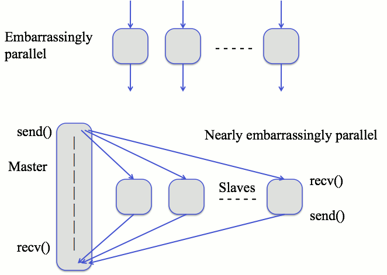

## Introduction

1.2 Map-reduce, Hadoop and Spark

- Here’s an example of `reduce()` in R.
- It’s also in the `purrr` library:

```r
t(reduce(c(1,2,3,4,5),function(x,y) x + y))
```

```
##      [,1]
## [1,]   15
```

- Here, `reduce` aggregates recursively from left to right,
- but when the reduce `function` is associative/commutative,
- we can be assured execution order won’t change the outcome.

## Introduction

1.2 Map-reduce, Hadoop and Spark

- When chained together,
- map-reduce operations can produce high-level outcomes
- that are *entirely scalable*.
- Here’s an example computing vector distance:

```r
x = c(1,7,4,2,78,35,3,6,2,6)
y = c(5,2,6,8,9,3,2,7,9,10)
d = reduce(map(x - y, function(z) z^2),
           function(a,b) a + b) ^ 0.5
print(d)
```

```
## [1] 77.02597
```

## Introduction

1.2 Map-reduce, Hadoop and Spark

- As discussed, map-reduce is a programming *pattern*.
- Early proprietary software was called this by Google,
- but open-source *Hadoop* software ultimately appeared.
- But it’s not just the map-reduce dance that Hadoop does!
- Hadoop also offers HDFS—a distributed file system.
- HDFS is *essential* for really big data,
- because it mixes processing with DFS,
- allowing most data to never pass through network.

## Introduction

1.2 Map-reduce, Hadoop and Spark

- Working with native Hadoop requires java, and
- while some libraries exist for R, Python, etc.,
- their function is often limited.
- Hadoop/HDFS is really for *very* large data,
- where so much exists you don’t want to move it around.
- While Hadoop uses disk well, it makes only limited use
- of memory, which provides fast data interaction.
- This (and more) is where spark comes in.

## Introduction

1.2 Map-reduce, Hadoop and Spark

- Spark is software supported by the makers of Hadoop,
- and focuses on in memory data utilization,
- in addition to robust processing,
- and more pre-defined, flexible user-friendly tools.
- Because it uses memory, it doesn’t need a DFS!
- So while Spark can connect to Hadoop as controller
- it can also be used on a laptop to max out resources!

## Introduction

1.2 Map-reduce, Hadoop and Spark

- Regardless of Hadoop or Spark, etc.,
- map-reduce is the scheme and has one other component.
- Data are often paired with labels (keys),
- that organize handoff between map and reduce.
- this handoff is called the *shuffle*,
- which really just means a sorting by label.

## Introduction

1.3 Map-reduce, Hadoop and Spark

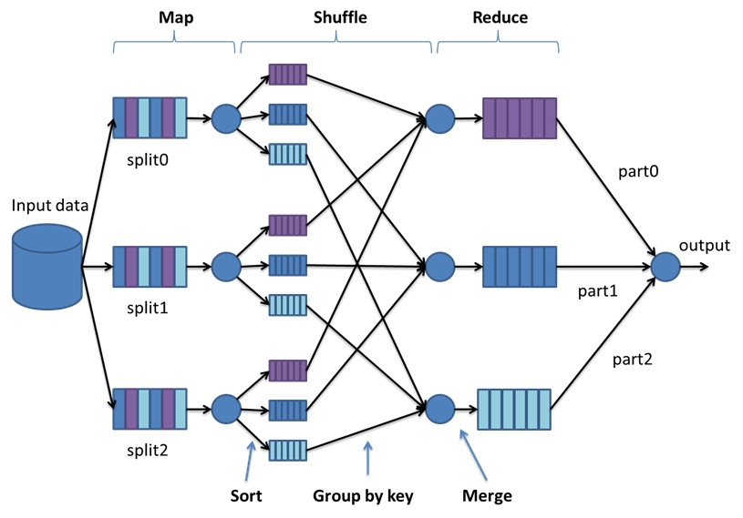

## Introduction

1.3 Configuration

- `SparkR` is an R library and can be installed like usual
- It’s documentation can be found [here](https://spark.apache.org/docs/2.2.0/api/R/index.html) on CRAN:
- But SparkR will likewise require java,
- since that’s really doing the work in the background.
- Note: you must use java version 8 for `SparkR`,
- so download from [here](https://www.oracle.com/technetwork/java/javase/downloads/jdk8-downloads-2133151.html).
- Likewise, there’s documentation on the [developer’s site](https://spark.apache.org/docs/latest/sparkr.html),
- and lots of helpful tutorials, like [this one](https://docs.databricks.com/spark/latest/sparkr/overview.html#sparkr-in-notebooks) from databricks.

## Introduction

1.4 Types of SparkR operations

- Spark funcations fall into *transformations* and *actions*.
- The distinction is part of what helps make spark scalable.
- Transformations are not executed until *necessary*,
- while actions force all preceeding tranformations to run,
- and ultimately result in output.

## Introduction

1.4 Types of SparkR operations

- This lazy strategy minimizes `SparkR`’s workload and
- allows `SparkR` to consolidate operations,
- making processing decisions obscured from users,
- further optimizing the evaluation of expressions.
- So don’t be surprised if it looks like nothing happens!
- This probably means your ‘transforming’ data,
- and need to invoke an action to get a result.

# Section 2

## Basic `SparkR` usage

## `SparkR` Usage

2.1 Starting a session

- Starting a `SparkR` requires knowing the desired threads,
- e.g., `master = 'local[4]'` creates 4 local threads,
- and `spark.driver.memory` sets the memory per thread.
- This let’s us squeeze the most of available resources

  ```r
  library(SparkR)
  sparkR.session(master = 'local[4]',
                 sparkConfig = list(spark.driver.memory = '4g'))
  ```

  ```
  ## Launching java with spark-submit command /Users/jw3477/Library/Caches/spark/spark-2.4.3-bin-hadoop2.7/bin/spark-submit   --driver-memory "4g" sparkr-shell /var/folders/fb/tvzcq7n54092b6w7vby4g__jsgbgxk/T//RtmpIAtkSn/backend_port191522e8daef
  ```

  ```
  ## Java ref type org.apache.spark.sql.SparkSession id 1
  ```

- Important: determine thread/memory capacities of your system!

## `SparkR` Usage

2.1 Starting a session

- Next, we might want data in our session.
- This is easy with the `read.df()` command,
- and we can still check dimensions and names:

```r
  loans = read.df("./data/loan.csv", source = "csv",
                  header="true", inferSchema = "true")
  print(dim(loans))
```

```
## [1] 887379     74
```

```r
  print(names(loans))
```

```
##  [1] "id"                          "member_id"
##  [3] "loan_amnt"                   "funded_amnt"
##  [5] "funded_amnt_inv"             "term"
##  [7] "int_rate"                    "installment"
##  [9] "grade"                       "sub_grade"
## [11] "emp_title"                   "emp_length"
## [13] "home_ownership"              "annual_inc"
## [15] "verification_status"         "issue_d"
## [17] "loan_status"                 "pymnt_plan"
## [19] "url"                         "desc"
## [21] "purpose"                     "title"
## [23] "zip_code"                    "addr_state"
## [25] "dti"                         "delinq_2yrs"
## [27] "earliest_cr_line"            "inq_last_6mths"
## [29] "mths_since_last_delinq"      "mths_since_last_record"
```

[output cut: 22 more lines]

## `SparkR` Usage

2.2 Sorting and collecting data

- sparkR functions may have different names from base R
- for example, we want `arrange(x, col)` for sorting.
- Notice the negative used for a reverse (high to low) sort

```r
sorted_loans = arrange(loans, -loans$funded_amnt)
```

## `SparkR` Usage

2.2 Sorting and collecting data

- But wait, where’s the output?
- Well, `arrange` is a transformation
- and we need an action to get a result.
- `collect(x)` executes a whole process (costly)
- while `head(x, n) let’s us just see n results:

```r
head(sorted_loans, 5)
```

```
##        id member_id loan_amnt funded_amnt funded_amnt_inv       term
## 1 1057239   1288798     35000       35000        32763.06  60 months
## 2 1056174   1287750     35000       35000        35000.00  36 months
## 3 1055282   1286844     35000       35000        35000.00  36 months
## 4 1059310   1291114     35000       35000        35000.00  36 months
## 5 1065896   1300036     35000       35000        35000.00  36 months
##   int_rate installment grade sub_grade                   emp_title
## 1    19.42      916.03     E        E3 Skanska USA Civil West, Inc
## 2     8.90     1111.37     A        A5                    Visa Inc
## 3    14.27     1200.82     C        C2                         IBM
## 4    16.77     1243.85     D        D2          Hines Interests LP
## 5     8.90     1111.37     A        A5                  Twitch LLC
##   emp_length home_ownership annual_inc verification_status  issue_d
## 1    8 years           RENT   195000.0            Verified Dec-2011
## 2  10+ years       MORTGAGE   106000.0            Verified Dec-2011
```

[output cut: 93 more lines]

## `SparkR` Usage

2.2 Sorting and collecting data

- Sometimes, we only want a few columns;
- for this, we’ll now have to use `select(x,cols)`:

```r
head(select(sorted_loans, c('funded_amnt')), 20)
```

```
##    funded_amnt
## 1        35000
## 2        35000
## 3        35000
## 4        35000
## 5        35000
## 6        35000
## 7        35000
## 8        35000
## 9        35000
## 10       35000
## 11       35000
## 12       35000
## 13       35000
## 14       35000
## 15       35000
## 16       35000
## 17       35000
## 18       35000
## 19       35000
## 20       35000
```

## `SparkR` Usage

2.3 Grouping and aggregation

- `SparkDataFrames` support common functions.
- For example you can `groupBy(x,col) a column
- and then `count()` the groups across the data easily:

  ```r
  head(count(groupBy(loans,loans$loan_status)), 5)
  ```

  ```
  ##                                          loan_status  count
  ## 1                                         Fully Paid 207723
  ## 2                                            Default   1219
  ## 3                                    In Grace Period   6253
  ## 4 Does not meet the credit policy. Status:Fully Paid   1988
  ## 5                                        Charged Off  45248
  ```

## `SparkR` Usage

2.4 Dataframe modification

- Dataframe operations feel native with `SparkR`.
- It’s easy to make a new column (remaining principle),
- as long as we’re sure to compare numeric values:

  ```r
  cast(loans$total_rec_prncp, 'double')
  ```

  ```
  ## Column CAST(total_rec_prncp AS DOUBLE)
  ```

  ```r
  loans$princ_rem =  loans$loan_amnt - loans$total_rec_prncp
  head(select(loans, loans$princ_rem), 5)
  ```

  ```
  ##   princ_rem
  ## 1      0.00
  ## 2   2043.54
  ## 3      0.00
  ## 4      0.00
  ## 5    766.90
  ```

- Note: `'double'` is a spark data type like R’s `'numeric'`,
- for a full range of type mapping, see [this page](https://spark.apache.org/docs/latest/sparkr.html#data-type-mapping-between-r-and-spark).

## `SparkR` Usage

2.5 Filtering values

- While arithmetic is handled,
- operating on a dataframe suse use spark build-ins
- For example, `filter()` lets us drill down:

  ```r
  incomp_loans = filter(loans, loans$princ_rem > 0)
  head(select(incomp_loans, incomp_loans$princ_rem), 5)
  ```

  ```
  ##   princ_rem
  ## 1   2043.54
  ## 2    766.90
  ## 3   1889.15
  ## 4   5437.98
  ## 5   4701.52
  ```

- We can really use any logical condition!

## `SparkR` Usage

2.6 Joining dataframes

- Sometimes matching rows on tables is needed,
- which is accomplished by `join(z,y,condition,jointype)`,
- where `z` and `y` are datframes
- `condition` is a logical expression for matching rows,
- and `jointype` is `'inner'`, `'outer'`, etc.
- To see Spark `join()`s in action, check out the Exercise!

## `SparkR` Usage

2.7 Joining dataframes

- Often, it’s not just data management we need to do.
- Perhaps there’s some analytics we need to scale out?
- In Hadoop we’d have to design map-reduce software,
- but entire implementations of ML algs. exist for spark.
- This provides the feel of working as we have before,
- when we were running algs. as serial processes.
- To explore the possibilities, check out [the docs](https://spark.apache.org/docs/latest/sparkr.html#algorithms)!